# Model fitting and selection using logistic regression

Nnamdi Joseph Asouzu

8/22/2021

**CASE STUDY**

Low birth weight data: The goal of this study was to identify risk factors associated with giving birth to a low birth weight baby (weighing less than 2500 grams). Data were collected on 189 women, 59 of which had low birth weight babies and 130 of which had normal birth weight babies. Four variables which were thought to be of importance were age, weight of the subject at her last menstrual period, race, and the number of physician visits during the first trimester of pregnancy.

**ID Meaning**  
LOW Low BirthWeight (0 = BirthWeight >= 2500g, 1 = Birth Weight < 2500g)  
AGE Age of the Mother in Years  
LWT Weight in Pounds at the Last Menstrual Period  
RACE Race (1 = White, 2 = Black, 3 = Other)  
SMOKE Smoking Status During Pregnancy (1 = Yes, 0 = No)  
PTL History of Premature Labor (0 = None 1 = One, etc.)  
HT History of Hypertension (1 = Yes, 0 = No)  
UI Presence of Uterine Irritability (1 = Yes, 0 = No)  
FTV Number of Physician Visits During the First Trimester (0 = None, 1 = One, 2 = Two, etc.)  
BWT Birth Weight in Grams

*Use the binary variable LOW as the response variable.*

**Analysis 1:**  
* Considering the four most clinically important variables previously discussed, i.e., age, weight of the subject at her last menstrual period, race, and the number of physician visits during the first trimester of pregnancy, carry out a model building exercise to determine the best model to describe the data. Based your model building exercise on the AIC and AIC weights. Discuss your results carefully.  
* Use backward elimination procedure to decide which predictor variables can be dropped from the regression model. Control the type I error at alpha <= 0.10 at each stage. Which variables are retained? How does this compare to the results obtained with the AIC?

**Analysis 2:**  
* Consider now the 8 covariates included in the data set (all except Birth Weight in Grams). Repeat the previous model building exercise using the AIC and the AIC weights. Compare the results of both analysis and make a careful discussion. * Use backward elimination procedure to decide which predictor variables can be dropped from the regression model. Control the type I error at alpha <= 0.10 at each stage. Which variables are retained? How does this compare to the results obtained with the AIC?  
Discuss.

**Conclusion:**  
Using the final model selected in the previous model building exercise (based on the AIC) answer the following scientific questions  
* What scientific insight does your final model offer?  
* Interpret the final model using the estimated coefficients and odd ratios.

Load necessary libraries

```r
suppressWarnings(suppressMessages(library("pastecs")))
suppressWarnings(suppressMessages(library("tidyverse")))
suppressWarnings(suppressMessages(library("PerformanceAnalytics")))
suppressWarnings(suppressMessages(library("AICcmodavg")))
suppressWarnings(suppressMessages(library("ROCR")))
suppressWarnings(suppressMessages(library("caret")))
```

**Import dataset**

```r
df <- read.table(file="C:/Users/Nnamdi/Desktop/Bioinformatics/Statistical_methods_for_bioinformatics/part_I/Projects/Project2/lowbwt.dat", header=T)
head(df)
```

|  | ID | LOW | AGE | LWT | RACE | SMOKE | PTL | HT | UI | FTV | BWT |
| --- | --- | --- | --- | --- | --- | --- | --- | --- | --- | --- | --- |
| 1 | 85 | 0 | 19 | 182 | 2 | 0 | 0 | 0 | 1 | 0 | 2523 |
| 2 | 86 | 0 | 33 | 155 | 3 | 0 | 0 | 0 | 0 | 3 | 2551 |
| 3 | 87 | 0 | 20 | 105 | 1 | 1 | 0 | 0 | 0 | 1 | 2557 |
| 4 | 88 | 0 | 21 | 108 | 1 | 1 | 0 | 0 | 1 | 2 | 2594 |
| 5 | 89 | 0 | 18 | 107 | 1 | 1 | 0 | 0 | 1 | 0 | 2600 |
| 6 | 91 | 0 | 21 | 124 | 3 | 0 | 0 | 0 | 0 | 0 | 2622 |

**Descriptive statistics**

```r
desc.df <- stat.desc(df[,c("AGE","LWT","RACE","SMOKE","PTL","HT","UI","FTV")], basic =T, desc=T)
desc.df
```

|  | AGE | LWT | RACE | SMOKE | PTL | HT | UI | FTV |
| --- | --- | --- | --- | --- | --- | --- | --- | --- |
| nbr.val | 189.0000000 | 1.890000e+02 | 189.00000000 | 189.00000000 | 189.00000000 | 189.00000000 | 189.00000000 | 189.00000000 |
| nbr.null | 0.0000000 | 0.000000e+00 | 0.00000000 | 115.00000000 | 159.00000000 | 177.00000000 | 161.00000000 | 100.00000000 |
| nbr.na | 0.0000000 | 0.000000e+00 | 0.00000000 | 0.00000000 | 0.00000000 | 0.00000000 | 0.00000000 | 0.00000000 |
| min | 14.0000000 | 8.000000e+01 | 1.00000000 | 0.00000000 | 0.00000000 | 0.00000000 | 0.00000000 | 0.00000000 |
| max | 45.0000000 | 2.500000e+02 | 3.00000000 | 1.00000000 | 3.00000000 | 1.00000000 | 1.00000000 | 6.00000000 |
| range | 31.0000000 | 1.700000e+02 | 2.00000000 | 1.00000000 | 3.00000000 | 1.00000000 | 1.00000000 | 6.00000000 |
| sum | 4392.0000000 | 2.453500e+04 | 349.00000000 | 74.00000000 | 37.00000000 | 12.00000000 | 28.00000000 | 150.00000000 |
| median | 23.0000000 | 1.210000e+02 | 1.00000000 | 0.00000000 | 0.00000000 | 0.00000000 | 0.00000000 | 0.00000000 |
| mean | 23.2380952 | 1.298148e+02 | 1.84656085 | 0.39153439 | 0.19576720 | 0.06349206 | 0.14814815 | 0.79365079 |
| SE.mean | 0.3854221 | 2.224323e+00 | 0.06679957 | 0.03559787 | 0.03588534 | 0.01778429 | 0.02590903 | 0.07705173 |

[output cut: 4 more lines]

```r
df$RACE <- as.factor(df$RACE)
df$FTV <- as.factor(df$FTV)
df$SMOKE <- as.factor(df$SMOKE)
df$PTL <- as.factor(df$PTL)
df$HT <- as.factor(df$HT)
df$UI <- as.factor(df$UI)
df$LOW <- as.factor(df$LOW)
```

**ANALYSIS 1**

**Exploratory data analysis**

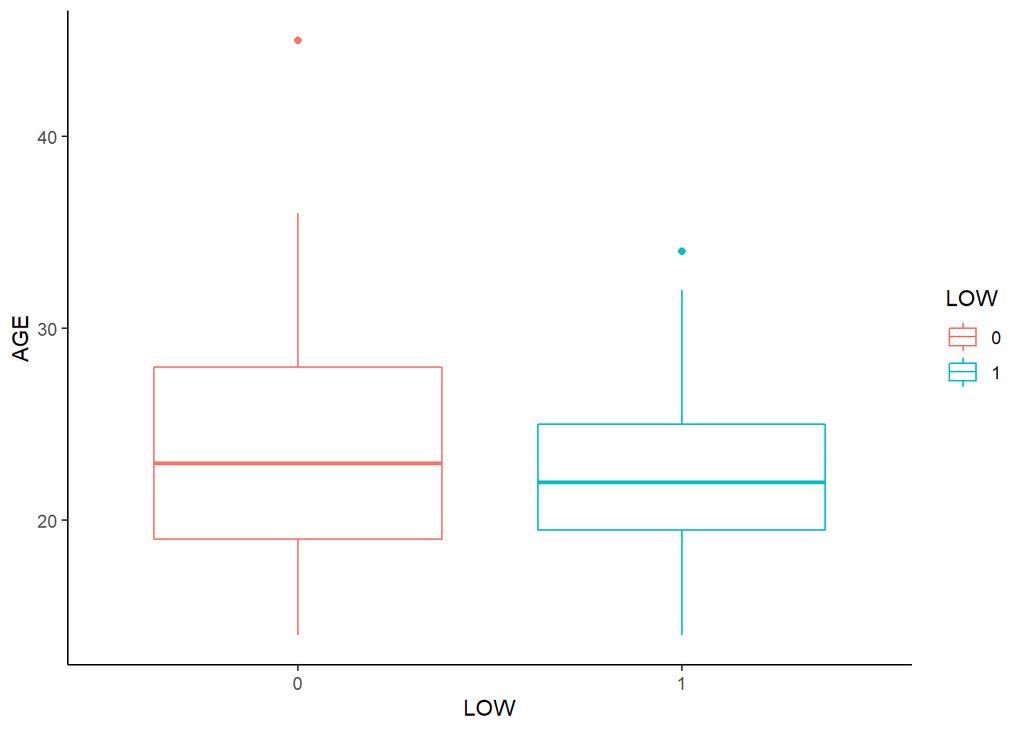

```r
ggplot(df,aes(LOW,AGE,color = LOW))+geom_boxplot() + theme_classic()
```

The boxplot show that older women had babies with birth weight > 2500g while younger women gave birth to babies with birth weight < 2500g. In other words, older women have low probability to give birth to babies with low birth weight.

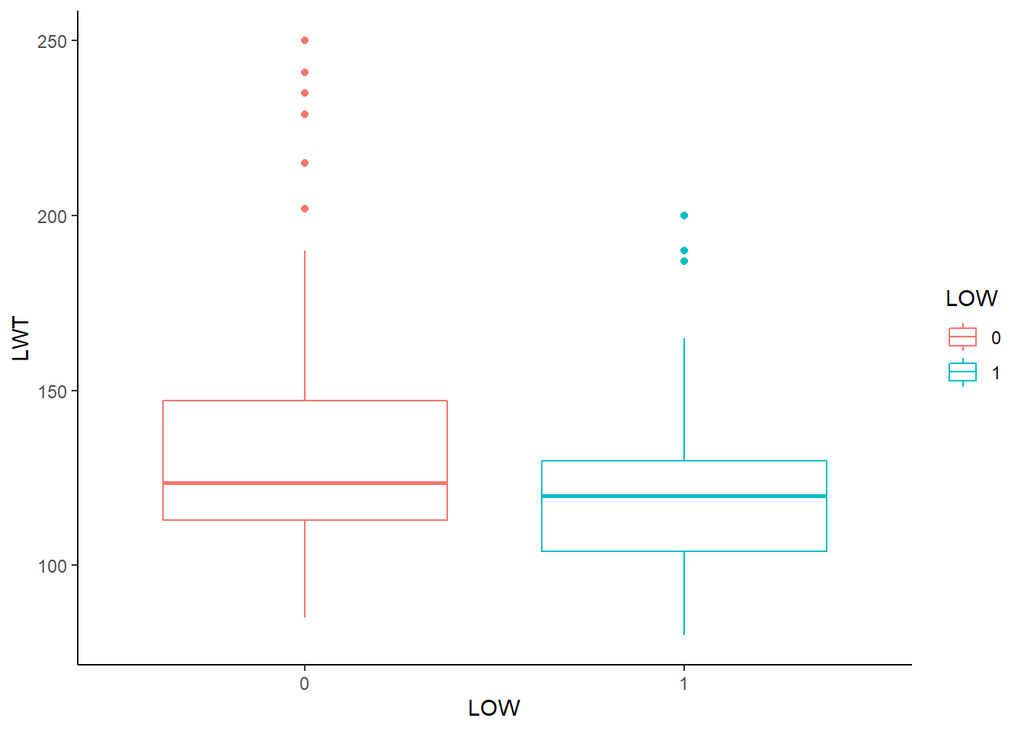

```r
ggplot(df,aes(LOW,LWT,color = LOW))+geom_boxplot() + theme_classic()
```

The boxplot shows that higher weight of women at their last menstrual period before pregnancy will decrease the probability of giving birth to babies with low birth weight.

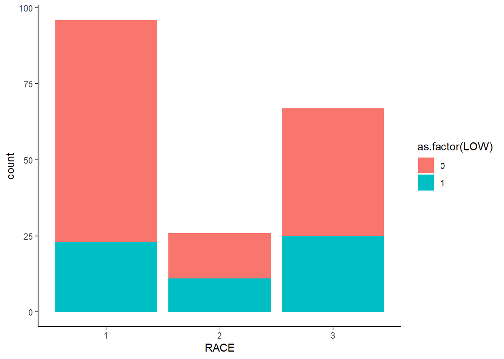

```r
ggplot(df)+geom_bar(aes(x=RACE, fill=as.factor(LOW)))+ theme_classic()
```

The barplot shows that pregnant women of black ancestry have higher probability of giving birth to babies with low birth weight compared to pregnant women of other ethnicity.

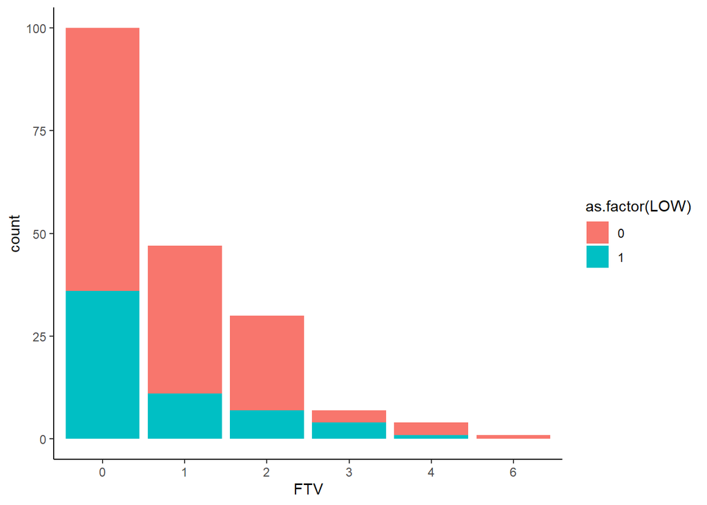

```r
ggplot(df)+geom_bar(aes(x=FTV, fill=as.factor(LOW)))+ theme_classic()
```

**Forward selection using AICc score**

```r
mod.list <- list()
mod.list[[1]] <- glm(LOW ~ AGE+LWT+RACE+FTV, data=df, family=binomial(link="logit"))
mod.list[[2]]<- glm(LOW ~ AGE*FTV+AGE*LWT+AGE*RACE+LWT*RACE+LWT*FTV+RACE*FTV, data = df,family=binomial(link="logit"))
mod.list[[3]] <- glm(LOW ~ LWT+RACE, data=df, family=binomial(link="logit"))
mod.list[[4]] <- glm(LOW ~ AGE+LWT+RACE, data=df, family=binomial(link="logit"))
mod.list[[5]] <- glm(LOW ~ FTV+RACE+AGE, data=df, family=binomial(link="logit"))
mod.list[[6]] <- glm(LOW ~ AGE+LWT+RACE+LWT*RACE, data=df, family=binomial(link="logit"))
mod.aictab=aictab(cand.set = mod.list)
mod.aictab
```

|  | Modnames | K | AICc | Delta_AICc | ModelLik | AICcWt | LL | Cum.Wt |
| --- | --- | --- | --- | --- | --- | --- | --- | --- |
| 3 | Mod3 | 4 | 231.4765 | 0.000000 | 1.000000e+00 | 6.276898e-01 | -111.62955 | 0.6276898 |
| 4 | Mod4 | 5 | 232.9885 | 1.512024 | 4.695351e-01 | 2.947224e-01 | -111.33032 | 0.9224122 |
| 6 | Mod6 | 7 | 235.9923 | 4.515794 | 1.045702e-01 | 6.563763e-02 | -110.68675 | 0.9880499 |
| 1 | Mod1 | 10 | 239.9403 | 8.463821 | 1.452461e-02 | 9.116951e-03 | -109.35217 | 0.9971668 |
| 5 | Mod5 | 9 | 242.2778 | 10.801342 | 4.513551e-03 | 2.833110e-03 | -111.63612 | 0.9999999 |
| 2 | Mod2 | 30 | 263.6239 | 32.147452 | 1.045369e-07 | 6.561672e-08 | -95.92589 | 1.0000000 |

The model fitted by forward selection technique using AICc score is LOW ~ AGE + LWT + RACE. Although this model did not have the lowest AICc score, it is logical to include the mother’s age as one of the predictors of the birth weight of a baby because it is known that maternal age affects the birth weight of babies as seen in published articles.

**Backward selection using p-value<0.10**

```r
bk.mod <- glm(LOW~AGE+LWT+RACE+FTV, data = df, family=binomial(link="logit"))
summary(bk.mod)
```

```
##
## Call:
## glm(formula = LOW ~ AGE + LWT + RACE + FTV, family = binomial(link = "logit"),
##     data = df)
##
## Deviance Residuals:
##     Min       1Q   Median       3Q      Max
## -1.4424  -0.8746  -0.6629   1.1966   2.0314
##
## Coefficients:
##               Estimate Std. Error z value Pr(>|z|)
## (Intercept)   1.202746   1.082863   1.111   0.2667
## AGE          -0.017692   0.034308  -0.516   0.6061
## LWT          -0.013654   0.006685  -2.042   0.0411 *
## RACE2         1.004965   0.504371   1.993   0.0463 *
## RACE3         0.410451   0.368470   1.114   0.2653
## FTV1         -0.505847   0.424518  -1.192   0.2334
## FTV2         -0.419576   0.498865  -0.841   0.4003
## FTV3          0.918398   0.815940   1.126   0.2603
## FTV4         -0.433857   1.202591  -0.361   0.7183
## FTV6        -12.270480 882.743860  -0.014   0.9889
## ---
## Signif. codes:  0 '***' 0.001 '**' 0.01 '*' 0.05 '.' 0.1 ' ' 1
##
## (Dispersion parameter for binomial family taken to be 1)
##
##     Null deviance: 234.67  on 188  degrees of freedom
## Residual deviance: 218.70  on 179  degrees of freedom
## AIC: 238.7
##
## Number of Fisher Scoring iterations: 13
```

Remove variables with p-value above the cut-off score

```r
bk.mod2 <- update(bk.mod, . ~ . - FTV, data = df)
summary(bk.mod2)
```

```
##
## Call:
## glm(formula = LOW ~ AGE + LWT + RACE, family = binomial(link = "logit"),
##     data = df)
##
## Deviance Residuals:
##     Min       1Q   Median       3Q      Max
## -1.4052  -0.8946  -0.7209   1.2484   2.0982
##
## Coefficients:
##              Estimate Std. Error z value Pr(>|z|)
## (Intercept)  1.306741   1.069786   1.221   0.2219
## AGE         -0.025524   0.033252  -0.768   0.4427
## LWT         -0.014353   0.006523  -2.200   0.0278 *
## RACE2        1.003822   0.498014   2.016   0.0438 *
## RACE3        0.443461   0.360257   1.231   0.2183
## ---
## Signif. codes:  0 '***' 0.001 '**' 0.01 '*' 0.05 '.' 0.1 ' ' 1
##
## (Dispersion parameter for binomial family taken to be 1)
##
##     Null deviance: 234.67  on 188  degrees of freedom
## Residual deviance: 222.66  on 184  degrees of freedom
## AIC: 232.66
##
## Number of Fisher Scoring iterations: 4
```

Age has a p -value greater than 0.1 but we will include it in the model because it is known that maternal age affects birth weight of babies (a condition known as Macrosomia).  
The model fitted by backward selection technique using control p-value less than 0.10 is  
**LOW ~ AGE + LWT + RACE**. This model is same as the model fitted using the forward selection.

**ANALYSIS 2**

**Exploratory data analysis**

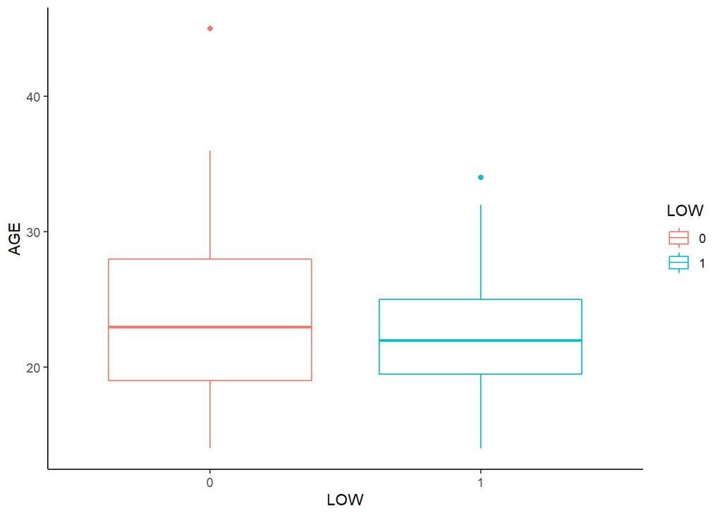

```r
ggplot(df,aes(LOW,AGE,color = LOW))+geom_boxplot() + theme_classic()
```

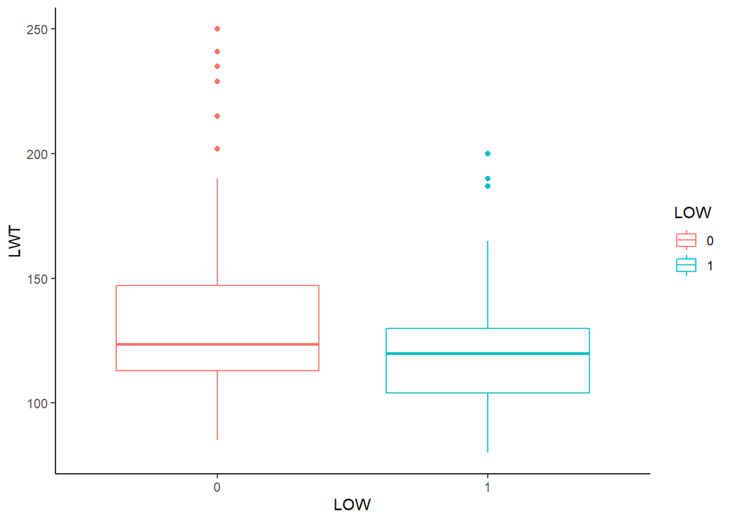

```r
ggplot(df,aes(LOW,LWT,color = LOW))+geom_boxplot() + theme_classic()
```

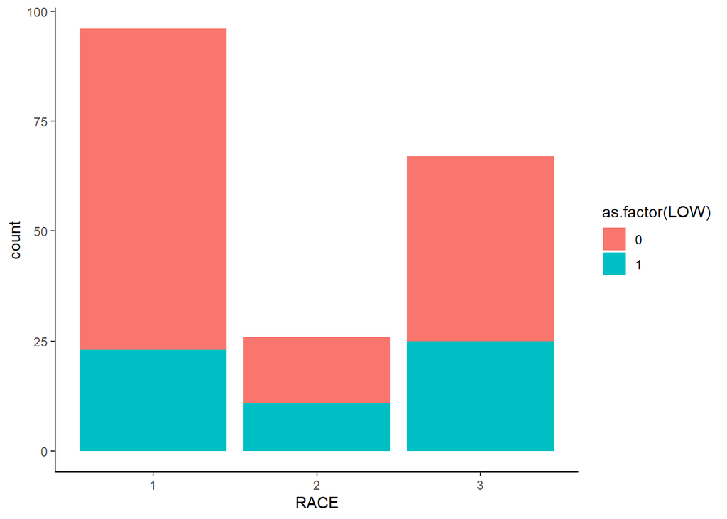

```r
ggplot(df)+geom_bar(aes(x=RACE, fill=as.factor(LOW)))+ theme_classic()
```

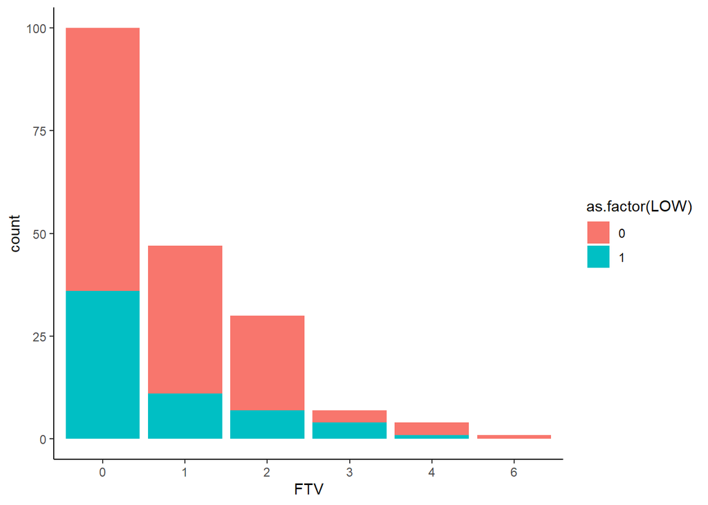

```r
ggplot(df)+geom_bar(aes(x=FTV, fill=as.factor(LOW)))+ theme_classic()
```

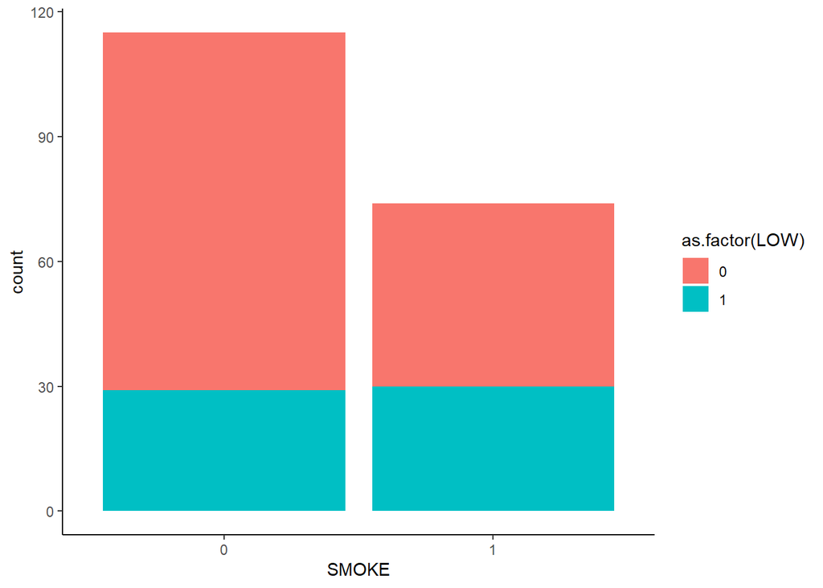

```r
ggplot(df)+geom_bar(aes(x=SMOKE, fill=as.factor(LOW)))+ theme_classic()
```

The barplot show that women who smoked during pregnancy had babies with low birth weight compared to non-smokers pregnant women.

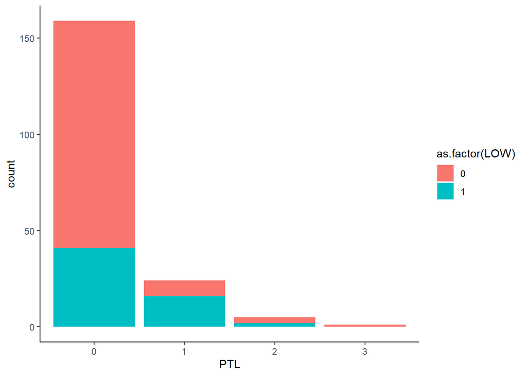

```r
ggplot(df)+geom_bar(aes(x=PTL, fill=as.factor(LOW)))+ theme_classic()
```

The barplot show that women who had 3 premature labor terms did not give birth to babies with low birth weight

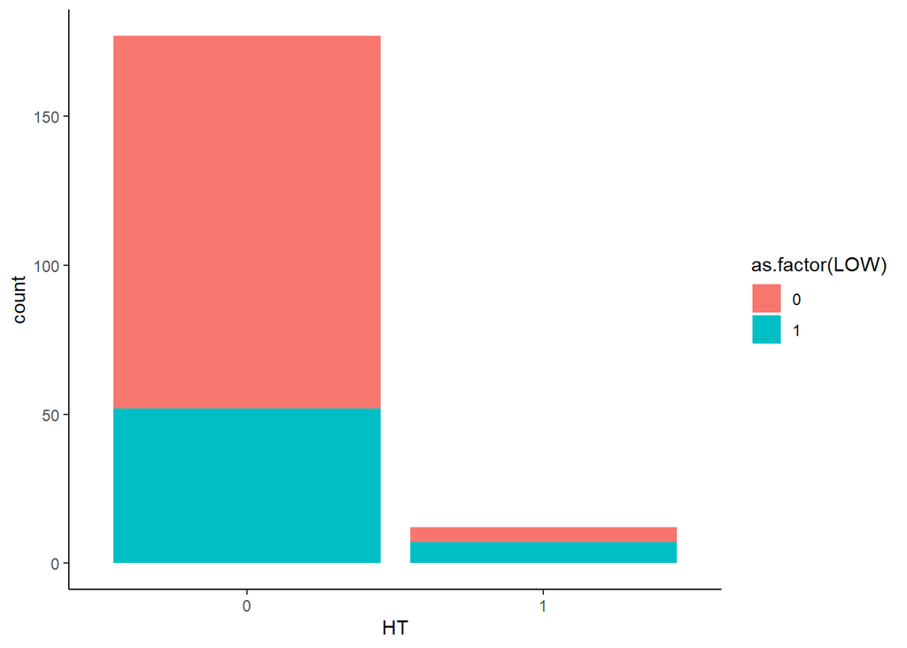

```r
ggplot(df)+geom_bar(aes(x=HT, fill=as.factor(LOW)))+ theme_classic()
```

The barplot shows that women who have a history of hypertension had babies with low birth weight compared to women who do not have a history of hypertension.

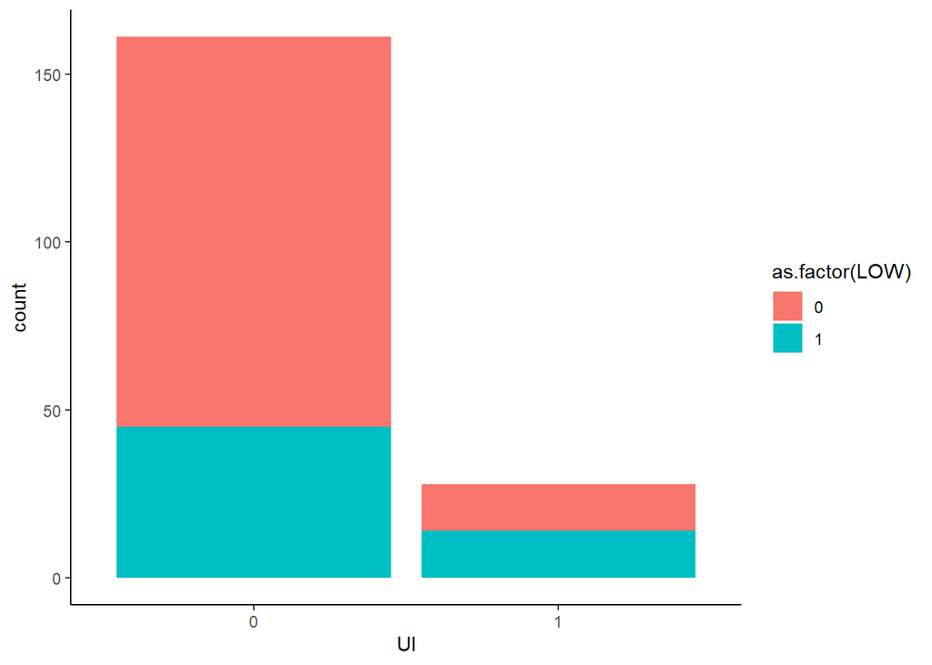

```r
ggplot(df)+geom_bar(aes(x=UI, fill=as.factor(LOW)))+ theme_classic()
```

The barplot show that women who have urinary irritability have higher probability of giving birth to babies with low birth weight compared to women without uterine irritability.

**Model fitting using forward selection technique and AICc**

```r
mod.list2 <- list()

mod.list2[[1]] <- glm(LOW ~ AGE+LWT+RACE+SMOKE+PTL+HT+UI+FTV, data=df, family=binomial(link="logit"))
mod.list2[[2]]<- glm(LOW ~ LWT+RACE+SMOKE+PTL+HT+UI, data = df, family=binomial(link="logit"))
mod.list2[[3]] <- glm(LOW ~ AGE+LWT+RACE+SMOKE+PTL+HT+UI, data = df, family=binomial(link="logit"))
mod.list2[[4]] <- glm(LOW ~ LWT*RACE+LWT*SMOKE+LWT*PTL+LWT*HT+LWT*UI, data=df, family=binomial(link="logit"))
mod.list2[[5]] <- glm(LOW ~ AGE+RACE*HT+RACE*UI+LWT*RACE+SMOKE*PTL+SMOKE*HT+SMOKE*RACE, data=df, family=binomial(link="logit"))
mod.list2[[6]] <- glm(LOW ~ LWT+RACE+SMOKE+PTL+HT+UI+RACE*UI, data=df, family=binomial(link="logit"))

mod.aictab2=aictab(cand.set = mod.list2)
mod.aictab2
```

|  | Modnames | K | AICc | Delta_AICc | ModelLik | AICcWt | LL | Cum.Wt |
| --- | --- | --- | --- | --- | --- | --- | --- | --- |
| 2 | Mod2 | 10 | 214.8265 | 0.000000 | 1.0000000000 | 0.5202638567 | -96.79526 | 0.5202639 |
| 3 | Mod3 | 11 | 215.9457 | 1.119199 | 0.5714377599 | 0.2972984129 | -96.22707 | 0.8175623 |
| 6 | Mod6 | 12 | 217.1414 | 2.314940 | 0.3142803387 | 0.1635087011 | -95.68434 | 0.9810710 |
| 4 | Mod4 | 17 | 222.2311 | 7.404663 | 0.0246659512 | 0.0128328029 | -92.32609 | 0.9939038 |
| 1 | Mod1 | 16 | 223.7602 | 8.933750 | 0.0114831448 | 0.0059742652 | -94.29872 | 0.9998780 |
| 5 | Mod5 | 22 | 231.5432 | 16.716777 | 0.0002344219 | 0.0001219612 | -90.72343 | 1.0000000 |

The model fitted by forward selection technique using AICc score is  
**LOW ~ AGE+LWT+RACE+SMOKE+PTL+HT+UI**. Although this model did not have the lowest AICc score, it is logical to include the mother’s age as one of the predictors of the birth weight of a baby because it is known that maternal age influences the birth weight of babies as seen in published articles.

**Backward selection using p-value < 0.10**

```r
analysis2_mod <- glm(LOW ~ AGE+LWT+RACE+SMOKE+PTL+HT+UI+FTV, data=df, family=binomial(link="logit")) # full model
summary(analysis2_mod)
```

```
##
## Call:
## glm(formula = LOW ~ AGE + LWT + RACE + SMOKE + PTL + HT + UI +
##     FTV, family = binomial(link = "logit"), data = df)
##
## Deviance Residuals:
##     Min       1Q   Median       3Q      Max
## -1.7713  -0.7839  -0.4859   0.8305   2.1983
##
## Coefficients:
##               Estimate Std. Error z value Pr(>|z|)
## (Intercept)  8.986e-01  1.299e+00   0.692  0.48908
## AGE         -3.889e-02  3.952e-02  -0.984  0.32508
## LWT         -1.536e-02  7.483e-03  -2.052  0.04017 *
## RACE2        1.110e+00  5.509e-01   2.016  0.04382 *
## RACE3        6.698e-01  4.774e-01   1.403  0.16061
## SMOKE1       7.073e-01  4.399e-01   1.608  0.10784
## PTL1         1.865e+00  5.722e-01   3.259  0.00112 **
## PTL2         4.875e-01  1.008e+00   0.484  0.62858
## PTL3        -1.553e+01  1.455e+03  -0.011  0.99148
## HT1          1.805e+00  7.488e-01   2.410  0.01595 *
## UI1          7.930e-01  4.780e-01   1.659  0.09712 .
## FTV1        -5.598e-01  4.958e-01  -1.129  0.25879
## FTV2        -8.141e-02  5.447e-01  -0.149  0.88120
## FTV3         1.103e+00  8.648e-01   1.276  0.20213
## FTV4        -9.225e-01  1.384e+00  -0.667  0.50496
## FTV6        -1.291e+01  1.455e+03  -0.009  0.99292
## ---
## Signif. codes:  0 '***' 0.001 '**' 0.01 '*' 0.05 '.' 0.1 ' ' 1
##
## (Dispersion parameter for binomial family taken to be 1)
##
##     Null deviance: 234.67  on 188  degrees of freedom
## Residual deviance: 188.60  on 173  degrees of freedom
## AIC: 220.6
##
## Number of Fisher Scoring iterations: 14
```

Drop variables with p-value > 0.10

```r
clean.mod <- update(analysis2_mod, . ~ . - FTV, data = df)
summary(clean.mod)
```

```
##
## Call:
## glm(formula = LOW ~ AGE + LWT + RACE + SMOKE + PTL + HT + UI,
##     family = binomial(link = "logit"), data = df)
##
## Deviance Residuals:
##     Min       1Q   Median       3Q      Max
## -1.6597  -0.7834  -0.5067   0.9214   2.2290
##
## Coefficients:
##               Estimate Std. Error z value Pr(>|z|)
## (Intercept)   0.849439   1.254317   0.677  0.49827
## AGE          -0.040478   0.038404  -1.054  0.29188
## LWT          -0.016084   0.007211  -2.230  0.02572 *
## RACE2         1.148883   0.539830   2.128  0.03332 *
## RACE3         0.739073   0.456017   1.621  0.10508
## SMOKE1        0.861797   0.413525   2.084  0.03716 *
## PTL1          1.577333   0.525600   3.001  0.00269 **
## PTL2          0.299220   0.982607   0.305  0.76073
## PTL3        -14.593484 882.743549  -0.017  0.98681
## HT1           1.866946   0.713799   2.616  0.00891 **
## UI1           0.856093   0.474641   1.804  0.07128 .
## ---
## Signif. codes:  0 '***' 0.001 '**' 0.01 '*' 0.05 '.' 0.1 ' ' 1
##
## (Dispersion parameter for binomial family taken to be 1)
##
##     Null deviance: 234.67  on 188  degrees of freedom
## Residual deviance: 192.45  on 178  degrees of freedom
## AIC: 214.45
##
## Number of Fisher Scoring iterations: 13
```

The model fitted by backward selection technique using control p-value less than 0.10 is: LOW ~ AGE + LWT + RACE + SMOKE + PTL + HT + UI. This model is similar to the model fitted with forward selection technique and AICc. Age has a p -value greater than 0.1 but we will include it in the model because it is known that maternal age affects birth weight of babies (a condition known as Macrosomia).

**Conclusion**  
The final model using AICc criteria is LOW ~ AGE + LWT + RACE + SMOKE + PTL + HT + UI.

```r
final_model = glm(LOW ~ AGE + LWT + RACE + SMOKE + PTL + HT + UI, data=df, family=binomial(link="logit"))
summary(final_model)
```

```
##
## Call:
## glm(formula = LOW ~ AGE + LWT + RACE + SMOKE + PTL + HT + UI,
##     family = binomial(link = "logit"), data = df)
##
## Deviance Residuals:
##     Min       1Q   Median       3Q      Max
## -1.6597  -0.7834  -0.5067   0.9214   2.2290
##
## Coefficients:
##               Estimate Std. Error z value Pr(>|z|)
## (Intercept)   0.849439   1.254317   0.677  0.49827
## AGE          -0.040478   0.038404  -1.054  0.29188
## LWT          -0.016084   0.007211  -2.230  0.02572 *
## RACE2         1.148883   0.539830   2.128  0.03332 *
## RACE3         0.739073   0.456017   1.621  0.10508
## SMOKE1        0.861797   0.413525   2.084  0.03716 *
## PTL1          1.577333   0.525600   3.001  0.00269 **
## PTL2          0.299220   0.982607   0.305  0.76073
## PTL3        -14.593484 882.743549  -0.017  0.98681
## HT1           1.866946   0.713799   2.616  0.00891 **
## UI1           0.856093   0.474641   1.804  0.07128 .
## ---
## Signif. codes:  0 '***' 0.001 '**' 0.01 '*' 0.05 '.' 0.1 ' ' 1
##
## (Dispersion parameter for binomial family taken to be 1)
##
##     Null deviance: 234.67  on 188  degrees of freedom
## Residual deviance: 192.45  on 178  degrees of freedom
## AIC: 214.45
##
## Number of Fisher Scoring iterations: 13
```

**Interpretation - odds ratio**

```r
exp(final_model$coefficients)
```

```
##  (Intercept)          AGE          LWT        RACE2        RACE3       SMOKE1
## 2.338334e+00 9.603308e-01 9.840447e-01 3.154666e+00 2.093994e+00 2.367410e+00
##         PTL1         PTL2         PTL3          HT1          UI1
## 4.842026e+00 1.348807e+00 4.593361e-07 6.468512e+00 2.353945e+00
```

* For each unit increase in maternal age, the odds of giving birth to a baby with low birth weight decreases by 4%.  
* For each unit increase in the weight of the mother before her last menstrual period, the odds of giving birth to a baby with low birth weight decreases by 1.6%.  
* The odds of giving birth to a baby with low birth weight is 3.15 times higher if the mother is of black ancestry.  
* The odds of giving birth to a baby with low birth weight is 2.09 times higher if the mother is of other ethnicity excluding black or white ancestry.  
* The odds of giving birth to a baby with low birth weight is 2.37 times higher if the mother smoked during pregnancy.  
* The odds of giving birth to a baby with low birth weight is 4.84 times higher if the mother had one history of premature labor term.  
* The odds of giving birth to a baby with low birth weight is 6.47 times higher if the mother has hypertension .  
* The odds of giving birth to a baby with low birth weight is 2.35 times higher if the mother has uterine irritability.

**Model accuracy and predictions**  
Create training and test data sets

```r
set.seed(1110)
df_split = sort(sample(nrow(df), nrow(df)*0.8)) ## 80% of the dataset randomly selected
train<-df[df_split,]
test<-df[-df_split,]
train_mod <- glm(LOW ~ AGE + LWT + RACE + SMOKE + PTL + HT + UI,family = binomial(link = "logit"), data = train)
```

predictions

```r
pred <- predict(train_mod, newdata = test, type = "response")
results <- ifelse(pred > 0.5,1,0)
table(results,test$LOW)
```

```
##
## results  0  1
##       0 27  7
##       1  3  1
```

```r
Accuracy.logistic <- round(mean(results == test$LOW), digits = 2)*100
print(paste('The accuracy of the model is ',Accuracy.logistic,"%"))
```

```
## [1] "The accuracy of the model is  74 %"
```

```r
#print(paste('Test error is ',100-Accuracy.logistic,"%"))
```

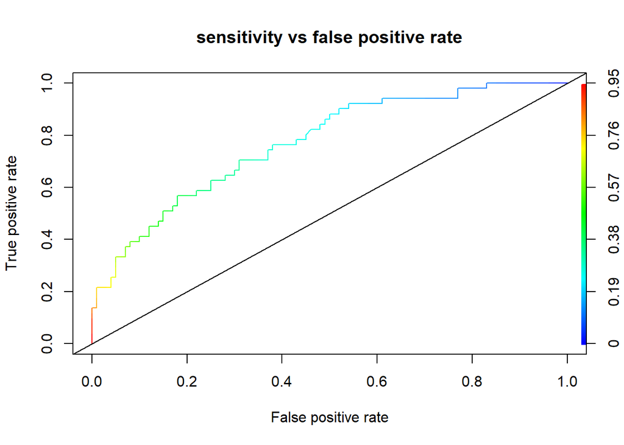

```r
predict <- fitted(train_mod)
pred <- prediction(predict, train$LOW)
perf <- performance(pred, measure = "tpr", x.measure = "fpr")
plot(perf, main="sensitivity vs false positive rate",colorize=TRUE)
abline(a = 0, b = 1)
```

ROCR and AUC

```r
auc_ROCR <- performance(pred, measure = "auc")
auc_ROCR <- auc_ROCR@y.values[[1]]
auc_ROCR
```

```
## [1] 0.769902
```